# Exploration of MPG Dataset

Grouping data by drive and then drawing scatter plot with estimated curve for each group:

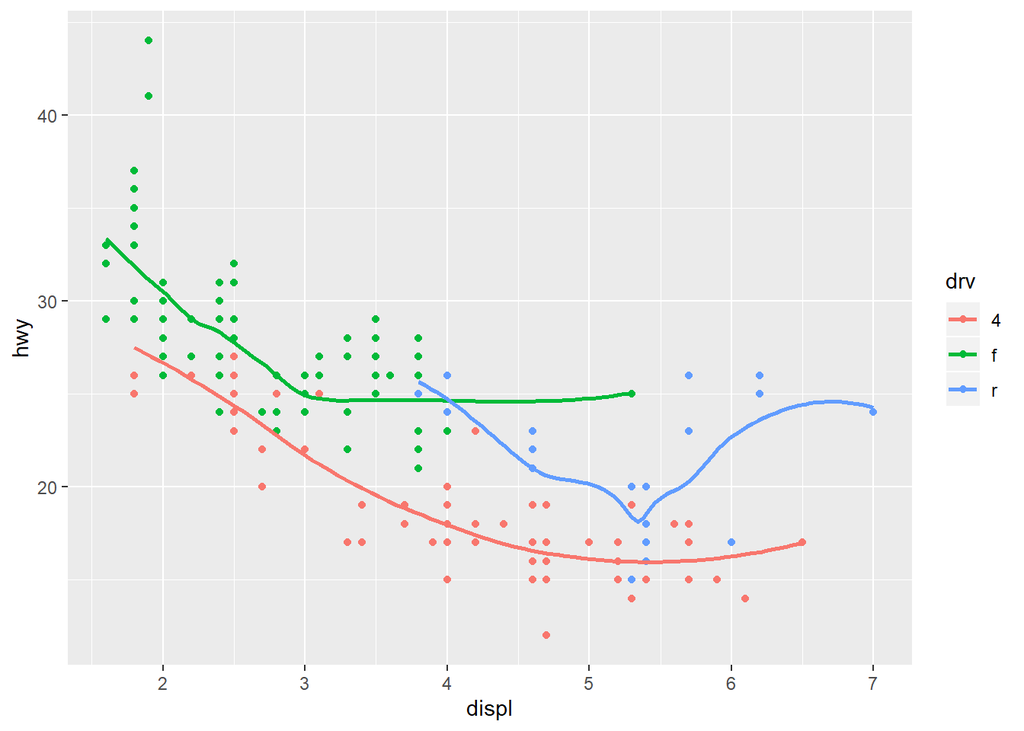

```r
ggplot(data = mpg, mapping = aes(x = displ, y = hwy, color = drv)) +
  geom_point() +
  geom_smooth(se = FALSE)
```

### Drive vs Cylinder

Visualizing the combinations of drives and cylinders available in the dataset:

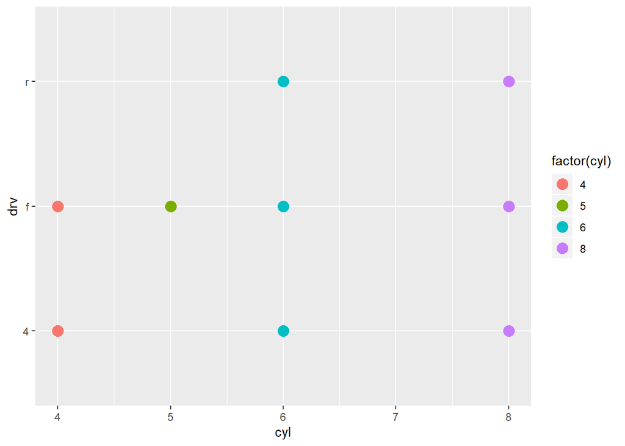

```r
ggplot(data = mpg) +
  geom_point(mapping = aes(y = drv, x = cyl, color=factor(cyl)), size=4)
```

### Is automatic transmission better?

We will create a copy of our data frame

```r
mpg2 <- mpg
```

We will introduce a new column defining whether the car is automatic or manual

```r
mpg2$is.automatic <- startsWith(mpg2$trans, 'auto')
mpg2$transmission <- ifelse(mpg2$is.automatic, 'auto', 'man')
```

Let’s verify the statistics

```r
table(mpg2$trans)
```

```
##
##   auto(av)   auto(l3)   auto(l4)   auto(l5)   auto(l6)   auto(s4)   auto(s5)
##          5          2         83         39          6          3          3
##   auto(s6) manual(m5) manual(m6)
##         16         58         19
```

```r
table(mpg2$is.automatic)
```

```
##
## FALSE  TRUE
##    77   157
```

Let’s compare the box plots of city mileage for the two types

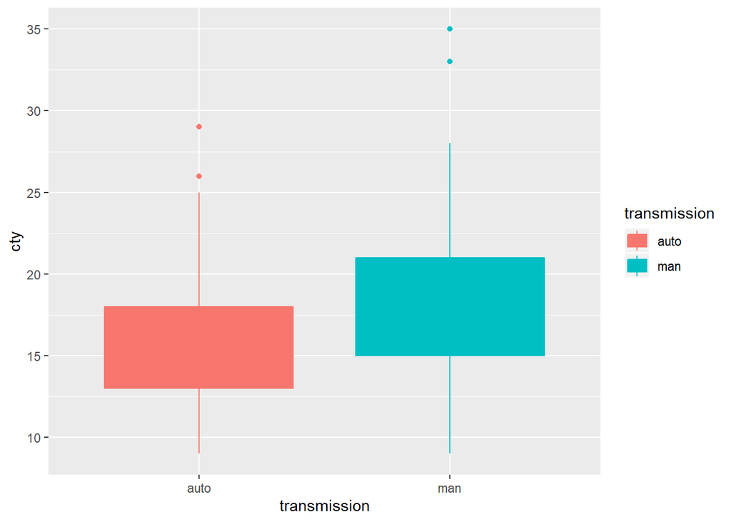

```r
qplot(transmission, cty, data=mpg2, geom='boxplot', fill=transmission, color=transmission)
```

This graphic suggests that the manual transmission is better than automatic one.

It is time for us to perform a t-test to verify the accuracy.

```r
manual.cty <- mpg2$cty[!mpg2$is.automatic]
auto.cty <- mpg2$cty[mpg2$is.automatic]
t.test(manual.cty, auto.cty, alternative = "two.sided", var.equal = FALSE)
```

```
##
##  Welch Two Sample t-test
##
## data:  manual.cty and auto.cty
## t = 4.5375, df = 132.32, p-value = 1.263e-05
## alternative hypothesis: true difference in means is not equal to 0
## 95 percent confidence interval:
##  1.527033 3.887311
## sample estimates:
## mean of x mean of y
##  18.67532  15.96815
```

The p-value is very low. It indicates strong evidence against the null hypothesis, so we reject the null hypothesis and accept that means are not equal.

Let’s also verify the hypothesis that mean of manual is greater than mean of automatic transmission.

```r
t.test(manual.cty, auto.cty, alternative = "greater", var.equal = FALSE)
```

```
##
##  Welch Two Sample t-test
##
## data:  manual.cty and auto.cty
## t = 4.5375, df = 132.32, p-value = 6.317e-06
## alternative hypothesis: true difference in means is greater than 0
## 95 percent confidence interval:
##  1.718907      Inf
## sample estimates:
## mean of x mean of y
##  18.67532  15.96815
```

Again we see that p-value is very very small. Thus, the alternate hypothesis must be true. Mean of manual transmission is greater than mean of automatic transmission.

```r
t.test(manual.cty, auto.cty, alternative = "less", var.equal = FALSE)
```

```
##
##  Welch Two Sample t-test
##
## data:  manual.cty and auto.cty
## t = 4.5375, df = 132.32, p-value = 1
## alternative hypothesis: true difference in means is less than 0
## 95 percent confidence interval:
##      -Inf 3.695437
## sample estimates:
## mean of x mean of y
##  18.67532  15.96815
```

Here p-value is 1. We don’t have any evidence supporting the alternate hypothesis.